# EnorNOC-GAM

Yu-Chen Xue

2018年6月13日

## GAM methods are implemented in R in the package mgcv.

## For visualizations packages ggplot2, grid and animation will be used. One useful function from package car will be used too.

## Let’s scan all of the needed packages.

## 1. Dataset介紹：

名稱：EnerNOC GreenButton Data  
來源：[open enernoc data](https://open-enernoc-data.s3.amazonaws.com/anon/index.html)  
簡述：該資料集由EnerNOC電力公司提供，它依循時間序列記錄了2012年100棟不記名的商業大樓每5分鐘的用電情況。  
解釋變數：  
- timestamp: 以秒為單位的絕對時間數值 (Type: int)  
- dttm_utc: 即datetime，日期與時間 (Type: chr)  
- value: 特定時間點下的電耗值 (Type: num)  
- estimated: 若為1表示當下的電耗值為估計值，否則為0 (Type: chr) - anomaly: 若有值表示當下的電耗值有誤，否則沒有值 (Type: chr)

## 2. 要用迴歸分析回答哪些問題

1. 電耗的日週期變化
2. 電耗的週週期變化

## 3. 使用的方法：

Generalized additive model (GAM)

## 4. 仔細的 model 解讀

```r
library(feather)
library(data.table)
library(mgcv)
library(car)
library(ggplot2)
library(grid)
library(animation)
```

讀取資料

```r
library(data.table)
library(feather)
DT <- as.data.table(read_feather("D:/WORKSPACE/RProjects/EnorNOC-GAM/DT_4_ind"))
```

使用package `car`中的function `record`，將週次改為interger

```r
DT[, week_num := as.integer(car::recode(week,
    "'Monday'='1';'Tuesday'='2';'Wednesday'='3';'Thursday'='4';
    'Friday'='5';'Saturday'='6';'Sunday'='7'"))]
```

從讀取的資料中獲取industry, date, weekday and period等信息，並使用變量來儲存。

```r
n_type <- unique(DT[, type])
n_date <- unique(DT[, date])
n_weekdays <- unique(DT[, week])
period <- 48
```

截取兩個禮拜內的商業用樓房的電耗記錄，並儲存在data_r變量中。之後畫圖展示之。

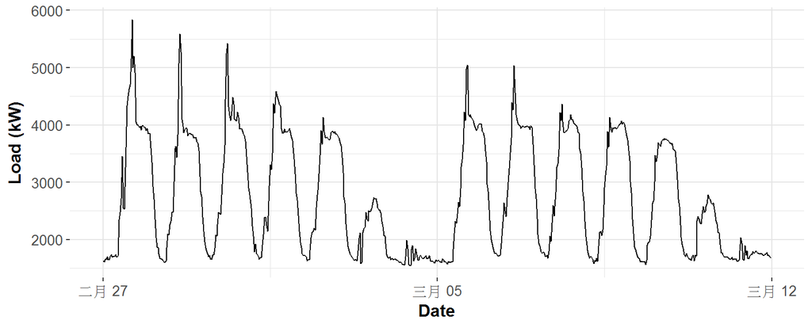

```r
data_r <- DT[(type == n_type[1] & date %in% n_date[57:70])]

ggplot(data_r, aes(date_time, value)) +
  geom_line() +
  theme(panel.border = element_blank(),
        panel.background = element_blank(),
        panel.grid.minor = element_line(colour = "grey90"),
        panel.grid.major = element_line(colour = "grey90"),
        panel.grid.major.x = element_line(colour = "grey90"),
        axis.text = element_text(size = 10),
        axis.title = element_text(size = 12, face = "bold")) +
  labs(x = "Date", y = "Load (kW)")
```

There is possible to see two main seasonalities in plotted time series: daily and weekly. We have 48 measurements during the day and 7 days during the week so that will be our independent variables to model response variable - electricity load. Let’s construct it: 根據每天的週期性變化和每週的週期性變化，重新構建資料

```r
N <- nrow(data_r) # train set中的資料筆數
window <- N / period # train set所囊括的天數
matrix_gam <- data.table(Load = data_r[, value],
                         Daily = rep(1:period, window),
                         Weekly = data_r[, week_num])
```

Here we are! Train our first **GAM** with function `gam`. Independent variables are modeled by smoothing function `s`, for daily seasonality cubic regression spline is used, for weekly seasonality, P-splines is used, a number of knots are logically set to the number of unique values. Let’s do it. 建立GAM模型，其中每天的週期性變化採用cubic regression spline模式來描述，每週的週期性變化採用P-splines來描述。

```r
gam_1 <- gam(Load ~ s(Daily, bs = "cr", k = period) +
               s(Weekly, bs = "ps", k = 7),
             data = matrix_gam,
             family = gaussian)
```

Package `mgcv` have many advantages and nice features. First is its visualization capabilities. Let’s try it: 作圖分析此模型

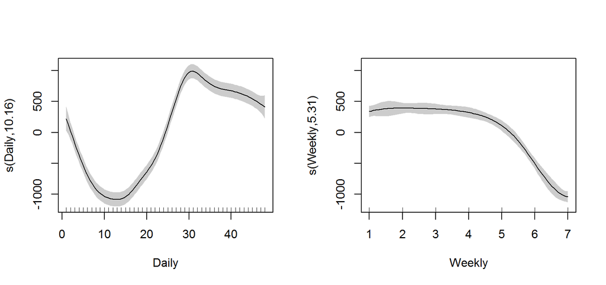

```r
layout(matrix(1:2, nrow = 1))
plot(gam_1, shade = TRUE)
```

在左圖中可以看出，用電高峰出現在下午3點；在右邊的圖中可以看出，週末的用電量小於平日。

查看模型的summary table

```r
summary(gam_1)
```

```
##
## Family: gaussian
## Link function: identity
##
## Formula:
## Load ~ s(Daily, bs = "cr", k = period) + s(Weekly, bs = "ps",
##     k = 7)
##
## Parametric coefficients:
##             Estimate Std. Error t value Pr(>|t|)
## (Intercept)  2731.67      18.88   144.7   <2e-16 ***
## ---
## Signif. codes:  0 '***' 0.001 '**' 0.01 '*' 0.05 '.' 0.1 ' ' 1
##
## Approximate significance of smooth terms:
##              edf Ref.df     F p-value
## s(Daily)  10.159 12.688 119.8  <2e-16 ***
## s(Weekly)  5.311  5.758 130.3  <2e-16 ***
## ---
## Signif. codes:  0 '***' 0.001 '**' 0.01 '*' 0.05 '.' 0.1 ' ' 1
##
## R-sq.(adj) =  0.772   Deviance explained = 77.7%
## GCV = 2.4554e+05  Scale est. = 2.3953e+05  n = 672
```

由summary table可以看出，根據p-value，電耗波動有很強的每天週期性變化和每週週期性變化。，Deviance explained數值不算很高，說明還有其他變量需要挖掘。

## 6. 課堂沒教的花俏的 r 指令

1. unique:獲取某欄位下的所有出現過的值
2. feather::read_feather: 讀取feather格式的資料
3. car::recode: 將資料重新編碼